# DV Assignment 2, Part 1: School-level differences in secondary school advice for similar test performance

Group 4: Sander van Nieuwenhuijzen, Natasha Medved, Sophie Preysing

2026-10-04

## Research question

“Do schools with similar test results give similar secondary-school advice?”

This research questions takes on an inferential approach. We analyse whether schools secondary-school advice is statistically related to school’s average test results. Through the use of an appropriate statistical model, we aim to find out if a significant relation between these variables exist. Our target audience consists of policymakers who need information on national patterns and the magnitude of the potential difference between schools. Therefore, our final data visualization will present statistical evidence for the relationship between test results and secondary school advice on a national level. The information will be presented in a way that is easy to digest for someone without a background in data science. The results can provide relevant information for public debate, development of policies and scientific progress in the field of education.

## Exploratory process

In the first exploratory plot we check whether schools advise higher or lower than their test results predict. Here, we compare its actual average advice against expected advice based on test results.

In the second plot we explore trend lines of the subjects language, maths and reading. We plot schoolweging against the percentage of students reaching target level and check the test results per schoolweging, per subject.

Lastly, we make a box plot of providers against schoolweging. The plot is visualized below here, we explore whether some providers have a more disadvantaged school population. A high score for schoolweging indicates a more disadvantaged school population. We ordered the schools from lowest median schoolweging (left) to highest median schoolweging (right). We learned that provider “DOE” has the lowest median schoolweging and provider “DIA” the highest. However, the medians for different providers fluctuate very little. This suggests that there is no significant difference in schoolweging between providers.

```r
source("../scripts/03-clean-data.R") # creates school_rq3
```

```
## Already have 'eindscores' (/Users/sandervannieuwenhuijzen/dv-2026-group4/data/raw/eindscores_2024-2025.csv) - skipping.
```

```
## Already have 'referentieniveaus' (/Users/sandervannieuwenhuijzen/dv-2026-group4/data/raw/referentieniveaus_2024-2025.csv) - skipping.
```

```
## Already have 'schooladviezen' (/Users/sandervannieuwenhuijzen/dv-2026-group4/data/raw/schooladviezen_2024-2025.csv) - skipping.
```

```
## Already have 'schoolweging' (/Users/sandervannieuwenhuijzen/dv-2026-group4/data/raw/schoolweging_2022-2025.ods) - skipping.
```

```
## eindscores: 6324 rows, 26 columns
```

```
## referentieniveaus: 6122 rows, 22 columns
```

```
## schooladviezen: 6385 rows, 25 columns
```

```
## schoolweging (2024-2025 sheet): 6312 rows, 6 columns
```

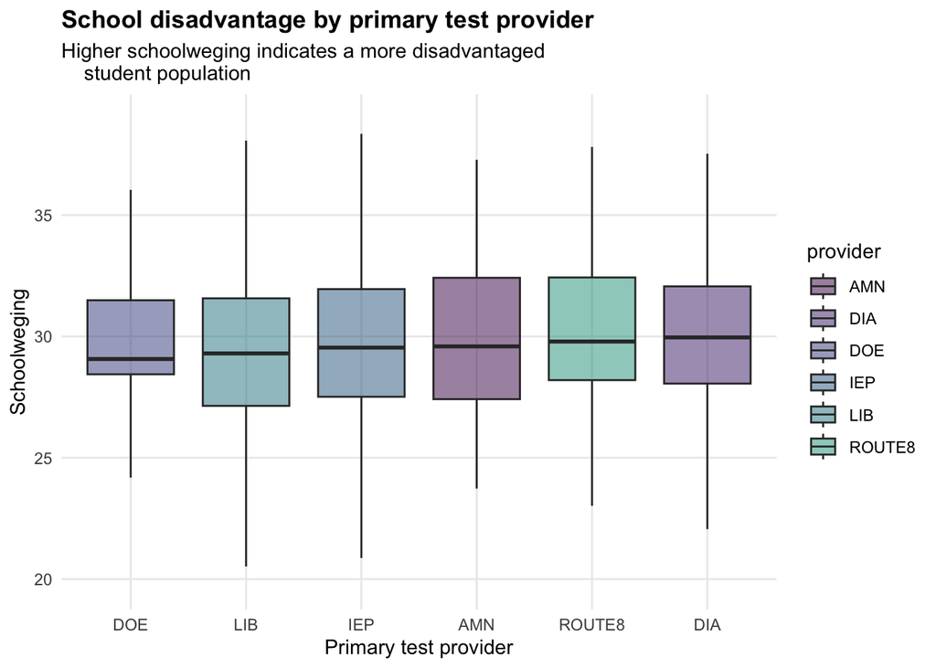

```r
viridis_colours <- viridisLite::viridis(10) # colourblind proof scheme

# shared theme, so all plots look alike
theme_explore <- theme_minimal(base_size = 11) +
  theme(panel.grid.minor = element_blank(),
        plot.title = element_text(face = "bold"))

plot_3 <- ggplot(school_rq3, aes(
  x = reorder(provider, schoolweging, FUN = median),
  y = schoolweging,
  fill = provider
)) +
  geom_boxplot(alpha = 0.5, outlier.shape = NA) +
  scale_fill_manual(values = viridis_colours) +
  scale_colour_manual(values = viridis_colours) +
  labs(
    title = "School disadvantage by primary test provider",
    subtitle = "Higher schoolweging indicates a more disadvantaged
    student population",
    x = "Primary test provider",
    y = "Schoolweging"
  ) +
  theme(plot.title = element_text(face = "bold"),
        axis.text.x = element_text(angle = 0, hjust = 0.5)) +
  theme_explore

plot_3
```